tech notes

# Python profiling and performance optimization example: a dijkstra-like algorithm

toy example of python performance diagnosis, profile and optimization

The code was written for [leetcode's minimum effort coding problem.](https://leetcode.com/problems/path-with-minimum-effort/)

Here is the original python code that is too slow to finish by leetcode's time limit.

```python
import itertools,sys


def getneighbors(x, y, rows, columns):
    steps = []
    if x > 0:
        steps.append((x - 1, y))
    if x < rows - 1:
        steps.append((x + 1, y))
    if y > 0:
        steps.append((x, y - 1))
    if y < columns - 1:
        steps.append((x, y + 1))

    return steps


def min_effort(heights):
    rows = len(heights)
    columns = len(heights[0])
    efforts = [list([sys.maxsize] * columns) for i in range(0, rows)]
    efforts[0][0] = 0
    spt = set()

    while len(spt) < rows * columns:
        unknown_set = set(itertools.product(range(0, rows), range(0, columns))).difference(spt)
        # pick the vertex with minimal effort, add it into known effort set, and update the effort of all its neighbors
        i, j = min(unknown_set, key=lambda xy: efforts[xy[0]][xy[1]])
        # i,j = next(ij for ij in unknown_set if efforts[ij[0]][ij[1]]<sys.maxsize)
        spt.add((i, j))

        neighbors = set(getneighbors(i, j, rows, columns))

        # adjust adjacent efforts of i,j
        for (x, y) in getneighbors(i, j, rows, columns):
            effort_via_ij = max(efforts[i][j], abs(heights[i][j] - heights[x][y]))
            if efforts[x][y] > effort_via_ij:
                efforts[x][y] = effort_via_ij

    return efforts[-1][-1]



heights = [[568198,495634,974168,682504,881437,931627,859885,426284,688762,346157,569045,760347,954795,639165,102706,118271,715664,371779,546983,29630,955190,298686,34299,555679,407912,817612,26484,99259,731418,538888,360258,844725,106916,134700,503794,326776,290108,21025,55811,413286,595177,226284,592672,920789,470479,650671,924595,425239,43648,557202,721130,429748,460669,568120,271684,417730,19158,740672,388964,954910,80164,768515,416132,265909,505833,891775,259134,990135,879766,279235,267619,158136,211632,995490,935226,245072,933069,677332,905032,829819,469820,384275,75451,253786,122284,922348,654840,293853],[457897,554741,70152,524477,904253,850151,693044,235976,637559,276459,28470,671342,593304,364638,676470,677464,447738,946516,603413,984390,706813,751389,599308,525623,971061,793191,6627,845731,731275,646099,203944,119276,628799,284196,372058,824364,506474,585055,624319,37071,799594,14735,146616,521852,889855,961258,906845,218651,242239,264816,368106,732724,242257,626440,144236,330187,269522,768197,377212,625406,735363,349463,859055,403168,167450,640589,744906,828140,375403,641395,575912,987264,313586,102629,328713,833054,791075,124371,370055,187610,840293,27429,107337,102768,22329,625692,278168,490607],[892400,246939,456864,658908,217762,589866,74323,592061,327947,267607,236818,985754,450476,950180,180873,421271,692860,948161,280390,326643,733974,365484,108293,401689,925402,784829,660465,397144,405366,58924,86204,292511,238144,503921,675731,197742,942734,538507,714040,951528,729231,634403,908419,817272,855112,649809,471583,837066,610453,894447,642515,268327,683229,741836,807581,300521,787314,995241,730923,376488,388295,389744,588815,944649,98935,464650,668393,412287,511544,450451,960971,98830,779658,670337,57690,453234,756358,102818,864512,541268,71761,130379,77356,198007,595235,865852,625061,615336],[762245,343661,839628,86839,412078,244895,865689,311455,488135,449369,707336,77042,673905,857228,509174,366863,825712,406677,305795,823057,302055,855722,858763,243697,825537,12537,613849,116654,689460,529799,546483,189798,96795,334041,448112,739737,44746,354538,136965,652985,937600,885966,938160,593531,725165,419350,118052,399796,69284,406682,678959,316570,758148,143381,676530,681781,55791,623998,109107,427477,682378,920780,379284,742316,686863,969786,291977,353655,119282,636109,22940,891532,649527,922382,735105,393332,146895,792707,496256,326763,357326,535204,792529,610164,476172,258153,614902,170899],[303947,529704,581805,562635,860602,227820,335717,82303,573584,49526,733217,723399,446008,347580,761729,514459,529221,287179,598835,310727,657582,866978,376237,448555,765576,776621,752900,87535,83012,928641,286500,178619,840148,473325,855864,69323,306056,289745,143498,522686,14995,665090,675282,479368,979646,776602,584228,550611,311702,934473,37260,935615,295211,224236,218334,581661,571130,26512,280298,159901,636166,952093,268454,457677,173009,64594,377914,161751,637564,42770,514857,755586,392307,156527,774606,549456,259278,723047,35353,566527,778886,6584,891623,54330,299736,508067,214530,667938],[894982,623507,44288,30454,307238,989804,722116,454847,229615,699667,495927,53673,351451,421738,640811,381307,750812,382042,293455,792997,916392,723186,889683,273110,667674,349240,220004,545088,378857,38823,774847,803735,511819,390600,183655,149252,850767,735487,794884,345512,299241,226764,738657,974903,469855,931502,931506,72455,827820,100175,898117,504703,853021,44173,312952,753935,256902,606385,289165,195239,276430,13773,488968,592803,749196,267152,616777,710253,974089,605656,240527,448212,917638,146389,507711,554749,703536,744812,488760,366134,139705,447015,496576,799484,327876,111365,963222,89098],[757720,860368,900265,314393,748521,364098,199948,542791,610906,955789,909389,798954,996981,933649,504516,56227,157995,469999,176643,273968,292743,516471,916338,559202,572592,609606,247124,710705,530470,320264,206796,244417,288597,293621,470479,290102,453500,566876,969345,961965,967915,770572,228608,600118,79794,37354,977247,404451,936855,135209,224071,135289,274177,526083,881728,968413,223414,147721,355637,809416,41269,369184,384162,224405,565766,649309,158664,836390,236758,853948,469981,658563,101810,66951,981030,129677,869045,776328,651628,744728,531841,175768,28416,456601,777776,670276,340190,778291],[107544,383579,241508,58152,641383,550256,666178,953561,542195,335284,559317,965035,477106,207845,177588,323739,85565,505445,997208,301032,651364,919328,513171,269122,949073,108472,405900,309648,893325,556194,741642,984076,144387,125475,696278,150980,947051,945267,494624,724614,264266,620311,58432,723775,72165,235687,665126,708109,87863,437007,853053,159565,664714,757833,112985,277225,694214,889607,879220,130229,10737,800238,364505,527800,425596,464678,183500,218961,605563,62478,250221,396384,245028,21203,490761,632104,226262,623282,771586,861742,933899,722133,477940,299183,719122,636067,652264,572544],[371144,337256,610627,727746,950227,398512,739258,433869,457499,664225,997180,476401,873592,289686,813021,497159,216810,386981,560797,652228,82587,452165,325848,378120,470046,323435,69590,335307,759776,36355,742982,914293,321397,88179,894820,800671,688631,978208,57956,182694,677075,305146,712474,717978,512468,745008,456401,905968,224304,479285,604611,822340,765854,85622,747662,271086,959033,183244,839548,962177,612291,939731,810815,461177,972501,602285,221146,361859,213004,920999,321815,381219,237204,539809,46898,471296,466362,702559,231236,795964,87011,545264,626437,627208,114646,60662,890394,859878],[713390,168212,862124,939543,503960,242076,539361,681505,146787,783214,585955,914003,439104,787654,553015,25199,206978,556579,875541,872103,802883,257006,588726,342313,316024,420640,783530,784216,863126,852872,502539,259648,778288,185973,270303,238203,161373,764343,683067,596097,479384,99375,397595,78444,366646,18187,140821,204143,152182,608851,345169,25917,696674,286284,151984,757529,286953,770688,509745,123181,817015,410931,401469,922418,251443,476777,500246,751906,751706,418193,901412,325323,896568,622653,273920,295297,831211,806407,367446,373971,207430,548212,131766,730578,199469,74041,786767,988553],[190,977750,365253,80839,233749,981013,981089,475797,893081,811136,624276,615275,534412,973027,110341,400997,195169,902664,221274,396634,603782,267778,620458,988794,670033,298350,812174,860336,925306,656034,704696,203234,316077,922546,58490,67687,435263,50619,274282,202101,489179,890076,941225,871195,388872,378907,3633,861897,590138,590257,549480,706980,733508,641472,420254,341321,954296,923665,321062,996623,121628,531896,512976,363821,473359,88336,851381,377826,674005,428232,879511,852714,149191,926245,859373,730545,408120,786370,578437,584826,795819,239897,997713,697761,597486,147129,581985,370498],[743884,390884,708323,92069,848288,10595,336916,799488,817342,679354,658774,710053,768896,340885,151533,102792,899133,789130,452653,151617,686383,4140,11218,337880,377450,752915,362723,632907,930152,744522,74143,820010,385313,762482,45054,388505,340645,838155,335097,970019,78609,650212,413455,383811,721096,830917,665619,959358,776061,873779,566890,578103,779954,458734,705686,117802,159281,351637,156596,764407,605641,647430,71808,994255,892943,425844,806415,126558,490898,267372,274640,182796,940933,961432,840731,93157,980069,283035,210896,867795,611161,71158,277583,522900,447252,221914,870564,161495],[572606,380805,484090,584410,193570,825000,525985,731474,836734,463038,383938,261935,314302,953729,817067,19678,305067,585000,382315,853005,783695,641416,813076,108073,628350,467449,575874,401362,548478,250597,921571,122233,376502,328700,746068,259638,808344,138470,232065,466675,795942,203465,422181,373867,716555,466309,367243,576748,866227,161153,461084,42382,263478,352836,935131,204277,721857,781254,659941,135975,929333,807118,397400,605715,906204,820195,310391,616443,170644,17782,116396,313489,71672,98591,92552,31110,336524,625603,397604,521068,412604,963550,186961,859590,69872,764826,332233,248167],[128202,658871,912559,30607,5831,316713,34691,866695,907351,439115,650620,258617,64435,593243,494976,189741,666343,290094,39701,335892,802875,62205,583729,863206,954856,841547,940212,274636,195314,352889,26203,589720,828238,185997,595447,388098,790894,506714,905101,386740,21780,607120,306042,78495,779794,429625,49252,495693,11546,884636,979962,932844,721133,964615,442253,52240,146734,84523,372292,468899,3010,772927,284129,130779,568233,799252,370172,690597,258952,339722,593541,464062,772761,453054,837228,97923,492595,328346,533288,9312,301090,352592,397131,812195,824874,526075,209827,875041],[878755,8224,873212,904484,785105,289729,748893,25795,764057,500913,655117,422740,513758,262845,935555,933825,402510,812302,79039,638029,852052,321046,649457,186514,352933,805824,583056,358235,548671,478764,606401,364532,330450,382301,38865,689198,280948,175641,390552,731276,589349,107502,704938,353769,867726,347991,483467,514263,34249,924087,336582,287700,684025,537867,638127,573385,330301,636841,936722,486616,293935,217343,405454,113107,750842,592577,514530,448051,453570,488928,622005,311671,743144,424399,995509,346133,40413,60311,767127,460122,560734,403244,579071,837903,779081,466481,301640,187617],[233661,943216,512693,837126,948508,645210,122663,33619,333591,360929,330316,651299,194945,56438,521879,266199,666353,748535,110630,745092,836545,634692,750148,214960,628827,387521,475732,872781,148460,813949,104474,278825,766361,703662,13710,313969,839445,8538,78105,264246,904974,176188,499460,926400,698108,69506,306142,271756,771325,828678,550466,908928,867437,649626,500480,764094,845262,895471,844468,170063,607241,732676,396696,854818,852354,169845,207956,179571,281268,627437,360733,753698,704148,700996,370382,300468,395666,227321,409057,400945,467221,93007,593222,442377,698677,105430,509095,104934],[979032,432985,290364,73257,190888,222112,149971,79126,939678,551566,538112,290338,857430,485692,227359,530983,799182,386203,319900,256452,243820,973504,470907,937723,858469,211399,953024,431147,279573,3897,834139,208319,6736,146687,275203,796211,151680,117611,616429,505854,203518,512953,260472,792783,945465,345259,493798,168682,964952,717534,198805,412363,953085,480096,98472,760747,422598,876372,381241,866074,668209,68380,655247,581324,840825,828231,98743,306678,619380,903880,679864,845976,763049,346462,177873,868063,708190,144681,716438,379381,553608,589446,613675,814322,785942,907497,834230,524681],[924571,250821,390483,213407,325497,193103,398596,491438,92006,964413,419595,802635,641800,18358,387119,115542,517079,305192,369037,151338,512004,416476,735254,881375,966913,164862,741305,210912,167581,392291,955859,863359,529018,601904,72218,580190,150329,416319,105107,601794,223048,698522,545565,551419,155494,652190,963290,194995,874921,726953,154418,134555,866375,467102,555192,544745,847372,252370,781360,786223,561883,960949,363278,468680,675392,306015,794368,228113,490086,732351,765054,684511,393416,223535,509714,902494,632757,676119,142319,863641,432615,540836,153677,393224,424346,594004,12431,397831],[479835,782364,195571,952448,449749,78199,652668,382200,146228,782441,294044,322386,82188,195524,73716,942021,693719,37101,127684,173216,331115,835445,333041,237171,879961,375744,920006,37360,27368,178170,43385,93579,360994,207811,759420,949410,538207,443896,274785,781248,95946,521384,763109,510059,870379,661550,537473,24161,368472,70330,521936,192096,535969,930594,343237,936780,815360,60155,908310,867656,520411,361095,499294,625762,903721,953367,450388,250287,981483,961683,334522,259266,918505,915052,43842,45926,555565,343768,79326,120691,224623,214551,764465,124886,550441,206529,104141,875471],[146748,104671,348032,558292,137859,785336,338704,526205,6768,995955,928711,195553,865690,556522,704726,985863,508510,3444,388377,405017,600501,202407,221600,958223,70576,498488,988622,504220,312796,415358,869100,9550,46246,470818,686044,371084,515703,563020,648526,10369,253863,411879,8293,572599,315823,199380,617011,984509,304620,137035,571864,352501,279056,626684,51046,958325,452305,355884,974362,905331,103250,714524,678732,174016,504438,979427,278368,148346,768713,587243,187783,13243,463164,822139,727723,257369,421306,817276,765397,717119,159656,167628,622163,259723,955849,223009,792370,744849],[10972,559053,419349,566995,230933,409725,84581,755602,981545,575549,567732,352772,931446,9649,997951,914849,226933,240531,902630,971366,976261,580969,741459,194224,881991,940421,937064,634503,443005,374839,371146,278446,478344,345876,105496,500611,902844,135795,6479,911922,719354,656840,160470,830241,247536,475275,562640,173645,656409,180471,279718,844117,135675,53025,501849,449622,547613,107426,497369,284250,385599,635904,313929,197419,338279,438212,641421,469402,821688,415885,658106,380263,562435,451686,694527,736478,212244,743666,581409,522526,808978,60044,31100,405620,473353,761101,926599,143728],[953755,744065,630102,297204,48437,712916,550506,498105,529162,44493,875769,80678,552992,499465,804164,136170,668052,419366,222647,334645,370822,326704,998369,180857,546149,315219,469413,100153,64552,430795,505106,735659,808051,927387,312257,704557,5614,878607,538095,777700,963334,963041,515446,637093,266732,801357,279510,374170,970654,132032,933690,759654,436026,509129,97450,176088,55404,62961,943101,982818,872767,207358,610564,580184,820259,593945,948017,696790,544777,289646,96991,405835,894087,560204,120861,83244,430723,322020,669113,413009,398793,103611,154800,100363,892252,205497,299295,682806],[441375,91664,273461,702537,771136,538316,787079,518264,825266,786556,358810,4043,940502,151630,76524,227835,409049,977207,352164,602083,103603,914171,927313,114853,789824,761529,275853,123175,942168,972580,110001,438679,156084,688241,582878,250495,24093,991869,190808,559863,104428,413374,948073,478098,543719,101952,931593,167234,812099,591232,690903,249383,164230,280123,824292,357918,528676,586572,162668,689802,169575,616331,698392,471585,465654,397177,278640,492473,604693,302604,310636,144149,562797,668577,30118,393325,628162,156415,150156,51811,291160,682581,500160,132812,233646,887694,711229,870999],[801550,519091,786411,47288,542477,579453,304581,521435,748983,872356,684085,475384,347116,142691,528939,772815,987976,527379,765555,761072,509133,632850,525054,891815,395928,773748,636389,168817,985026,900468,120321,606196,518568,749873,758032,562034,178278,430663,136086,615308,902098,127700,169109,423071,896256,425027,858327,524591,887320,795485,815202,370551,735849,330571,941344,986709,594642,796702,597568,601363,948659,63693,585556,806044,432230,144785,296537,21062,357228,275488,234314,632307,402138,168209,210185,410801,187698,974435,926452,517065,165613,311832,362561,267711,913828,706724,981174,733236],[802794,969580,591850,26763,725707,958292,157980,867590,726628,472914,870845,396242,5524,351137,814506,195741,858543,91005,351577,860492,368468,150300,639715,564140,861416,266631,524637,278648,6486,267296,376320,735640,239480,376139,545226,847366,719853,312609,666574,162072,297329,303685,567699,503553,137157,521257,628035,335639,484958,245740,283743,969690,814750,17389,516051,937132,134581,401097,9047,315148,186850,572355,809728,768655,123463,550304,642466,664014,367221,966126,930905,930022,435355,429540,979918,545785,353308,264224,450161,743139,207210,856879,544806,989693,389031,54367,264514,534638],[845097,793038,898641,571942,974409,380795,682269,239706,471305,310322,651954,470187,242537,982161,509448,202614,45106,37709,727658,46801,856814,483669,45132,475981,692919,464852,67355,60051,706716,928209,767581,39309,441162,71325,469698,778202,475579,964263,585795,125866,189644,327511,254097,986423,580782,562567,524154,275009,555414,979590,914477,202035,594804,567857,465176,228750,750046,320393,830074,854528,347765,357082,994389,853061,573585,495587,688595,514019,708873,342434,673156,255333,18769,506400,219453,13912,755354,368871,751802,691226,941048,740938,50332,672961,361569,490425,442497,955444],[819344,964657,69017,397014,938181,861257,399949,840002,972798,407467,908892,7283,84715,384444,583939,600662,502160,114276,67013,844405,862512,512385,410517,992961,510473,746636,340845,421694,94845,99331,333600,103696,26352,678398,292588,188034,58264,835607,980011,724710,731114,41965,525065,29520,69146,748126,757852,551364,584655,668680,990146,645767,939867,274745,979305,752344,428450,409832,673324,953689,996144,529946,457448,571460,722971,925182,566324,692179,102519,956954,197266,648772,607386,644882,836384,588053,232684,143075,221382,218757,868559,944577,40828,244575,677379,876890,119765,939548],[914664,650588,164344,778071,246094,290439,565838,46203,298882,643735,892185,224040,978815,766847,263290,599357,23494,495751,391338,855092,718997,225879,835895,450901,476855,576972,586009,438183,15677,834547,732589,495139,426137,531716,574993,576930,852879,271789,685521,604526,582664,596950,928463,452295,255059,610394,428909,269391,743113,262696,132541,335629,647663,637166,682720,861830,976884,43404,972511,587189,277726,94566,990534,431406,759772,782004,332699,14677,454098,304,727698,82641,498337,27737,894347,202802,912503,378957,361867,886213,732615,664827,53057,245592,617922,413136,974252,890501],[250829,839674,291410,865089,433315,972967,871937,94605,384518,62541,606893,352393,946194,261155,524696,72918,178647,625178,8273,86042,242940,303872,826054,574041,792403,769819,832697,58344,724913,171451,841395,21231,689542,666108,455659,194089,946911,241326,165419,35487,249639,746987,824659,497210,516760,125095,126833,159097,159682,307403,341118,817262,663297,341997,773080,278689,883100,6108,794431,785632,324788,746390,217106,457225,389318,269886,62365,620139,582072,805900,833757,563716,621681,224743,393002,77476,684909,453356,728111,130704,535531,932369,46366,483568,745823,805202,191480,249200],[983254,926430,46865,99473,985419,953869,99108,639922,339237,61142,653918,837568,788944,623512,728626,280171,295151,706520,948475,565741,699787,472288,592038,650207,639585,721173,190079,107146,748627,932315,30748,556617,912322,132473,161221,909374,41954,775999,397165,876912,941600,958591,435940,109504,330020,206114,512588,289668,716509,516532,344116,857279,237656,949303,442567,573437,822002,572430,134278,518027,792763,509752,570612,895886,639964,302314,651591,762414,477758,552316,656748,534153,431053,701944,580002,305678,604026,384789,944024,794657,890276,529839,177388,654337,774108,634087,748244,527475],[592574,879854,783347,777296,837280,130963,100859,335046,635328,316335,487357,626276,153350,816124,308510,301313,512645,209838,807828,193003,591706,199147,779819,374854,971148,123854,624544,90572,314165,44687,228492,477206,840850,309150,916990,445351,464789,59148,680693,883870,80514,676976,761704,836612,3348,863982,469292,942338,358721,292043,680070,540703,920107,791934,84383,315393,466745,413232,369570,490802,348864,702103,395397,509138,270217,559852,859193,630199,202842,254662,589785,436366,961729,852179,916703,3600,541959,640804,446244,670867,765622,346524,173079,669131,845790,833090,782606,442828],[38266,633002,675503,425646,355376,191568,939800,368732,74350,783918,947646,10426,862322,285430,416546,928027,543054,934271,666861,39485,158959,320940,156789,598450,55629,726384,790215,351131,392232,41233,353633,476216,194076,805562,226381,84013,964613,471342,256986,993592,994472,365329,621915,108333,497480,169762,845129,985273,113460,636274,58258,933724,563773,970951,88647,133680,373536,667379,812028,353054,929708,683666,460504,858096,208269,248207,325781,42769,833942,778055,128983,962536,815970,947483,646499,552391,306500,169745,40749,851236,660015,664433,648158,828763,406306,103758,155428,766705],[47031,100429,936101,917479,250390,540655,243518,85777,63201,732454,882767,949915,383620,952398,522734,459372,546948,785154,571190,28060,386372,348258,334502,606450,416354,764983,413511,17155,968651,182774,22562,513693,899584,18396,566147,71173,744880,49105,766157,729139,571008,994070,517598,39346,273769,427164,975930,735548,619357,714537,410799,903220,722841,373577,595185,501035,963511,753082,853517,587477,589383,673267,545599,300867,400269,787139,201034,102346,985321,729213,639973,922780,717567,109172,273936,791501,747889,977999,918646,207380,299043,392169,343469,420271,762388,294507,655685,650137],[241278,74536,537382,136330,58356,474594,360963,559612,226876,569585,38289,178489,146340,843483,627149,719640,706118,604443,674564,455902,851432,902170,837245,278027,444523,239006,384679,316184,883783,34107,365,47035,224111,230084,342526,629421,98204,432088,530364,905033,114799,877697,169129,897845,298704,846212,263624,970555,478086,416375,911337,266290,421535,151017,688693,111714,980738,130999,708658,114711,374931,67570,133534,873683,452282,122486,917407,328466,820685,255358,85606,100024,249742,363354,551737,13544,682999,97421,926740,188438,428072,167079,56101,127852,13878,810349,168353,327872],[336741,148378,990843,567939,656001,633480,390226,804657,514347,495086,971420,396221,606931,15726,529602,315453,792181,106398,30130,404487,89354,262093,74827,115289,417842,277843,998076,708026,4207,698338,469453,884018,45547,968820,458272,688327,162144,816237,874028,377418,332745,928847,979906,571399,316492,474323,359077,171450,85802,927590,410800,170825,430704,48047,759126,367745,312726,506164,104853,114774,788020,171647,958024,81619,675752,309078,186982,435623,963414,201030,425321,336185,47128,714272,206,876712,214565,262200,905053,967603,223472,875763,673786,852571,964571,149220,264317,344011],[845918,839575,981769,73917,288134,226187,492237,232747,546526,236665,686569,700301,997230,48562,213622,343455,632295,124257,813073,723565,751597,277102,32708,988727,189542,933881,833787,210193,80012,901092,911900,860971,846299,805956,656475,729416,45030,605641,580386,25295,800706,587414,559623,66516,7556,789031,439887,699665,674362,919611,721201,30550,707838,70571,42932,929045,919826,876122,247391,122714,712458,919932,980286,38600,450696,501441,634414,780056,790825,379608,297714,773812,306110,868258,207645,77019,620937,606738,712016,76020,675029,988514,943377,907657,236877,415736,871289,466272]]
```

```python
from timeit import timeit
timeit("min_effort(heights)", globals=globals(),number=10)/10
```

```
5.277143474700279
```

No wonder it exceeded leetcode's time limit.

Reading the code, we can see it's a modified dijkstra algorithm. Most of the computations probably happens in the while loop, and the for loop inside the while loop.

However, the apparent is not always right. Let's do some profiling!

## Profiling

```python
import cProfile as profile
```

```python
%load_ext snakeviz
```

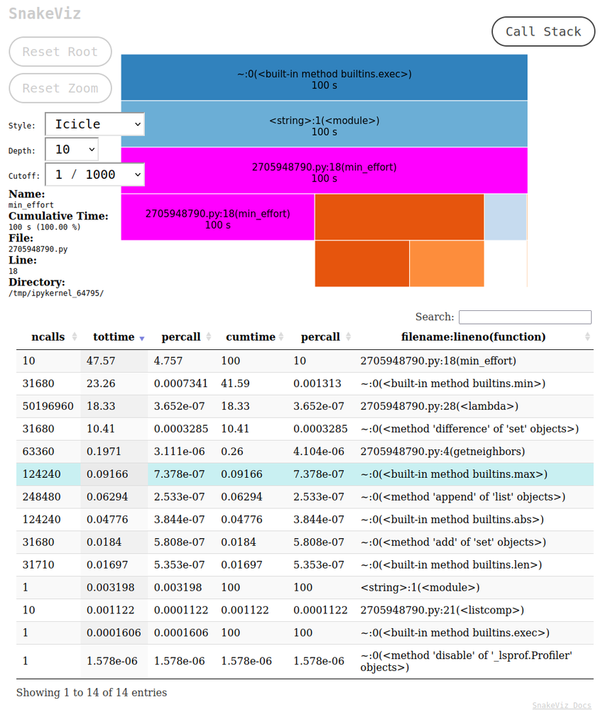

```python
%%snakeviz

for i in range(0,10):
    min_effort(heights)
```

What's surprising? The "min" function call use most cumulative time, including itself and its simple key function (lambda):

```
i, j = min(unknown_set, key=lambda xy: efforts[xy[0]][xy[1]])
```

The next time consuming is "set.difference()":

```
unknown_set = set(itertools.product(range(0, rows), range(0, columns))).difference(spt)
```

and the for (x, y) in getneighbors(i, j, rows, columns): block does not even use much time, so our initial conjecture from apparent code forms has to be revised.

Dijkstra's algorithm is usually implemented with a priority queue (heapq in python) to reduce time complexity of finding the currently known shortest path vertex. It takes O(klogn) in combined update and minimum finding, better than the min() function's O(n), k being the number of weight updates.

So what will we do to optimize this program? We first try retrofitting an existing [python dijkstra](https://gist.github.com/kachayev/5990802) code utilizing heapq. This code use adjacency list, so we convert our original chessboard grid 2D planar graph into the adjacency list format. Please excuse the cryptic code.

## python3 optimized code

```python
from collections import defaultdict
from heapq import *

def min_effort_dijkstra(edges, f, t):
    g = defaultdict(list)
    for l,r,c in edges:
        g[l].append((c,r))

    q, seen, mins = [(0,f,())], set(), {f: 0}
    while q:
        (cost,v1,path) = heappop(q)
        if v1 not in seen:
            seen.add(v1)
            path = (v1, path)
            if v1 == t: return (cost, path)

            for c, v2 in g.get(v1, ()):
                if v2 in seen: continue
                prev = mins.get(v2, None)
                # next = cost + c
                next = max(cost,c)
                if prev is None or next < prev:
                    mins[v2] = next
                    heappush(q, (next, v2, path))

    return float("inf"), None

def to_vertex_id(row,col, ncol):
    return col+row*ncol

def to_edges(heights):
    nrow = len(heights)
    ncol = len(heights[0])
    edges =[]

    for r in range(0,nrow):
        for c in range(0,ncol):
            v = to_vertex_id(r,c,ncol)
            neighbors = []
            for dr,dc in [(-1,0),(0,1),(1,0),(0,-1)]:
                if (r+dr)>=0 and (r+dr)<nrow and (c+dc)>=0 and (c+dc)<ncol:
                    neighbors.append((r+dr,c+dc))
            for nr,nc in neighbors:
                nv = to_vertex_id(nr,nc,ncol)
                edges.append((v,nv,abs(heights[r][c]-heights[nr][nc])))
    return edges

def min_effort2(heights):
    edges = to_edges(heights)

    return min_effort_dijkstra(edges,0,len(heights)*len(heights[0])-1)[0]
```

Let's first validate the correctness of this algorithm by comparing its result with the original code (Yes! it's correct)

```python
print(min_effort2(heights))
print(min_effort(heights))
```

```
344971
344971
```

```python
timeit("min_effort2(heights)", globals=globals(),number=100)/100
```

```
0.046792546779906845
```

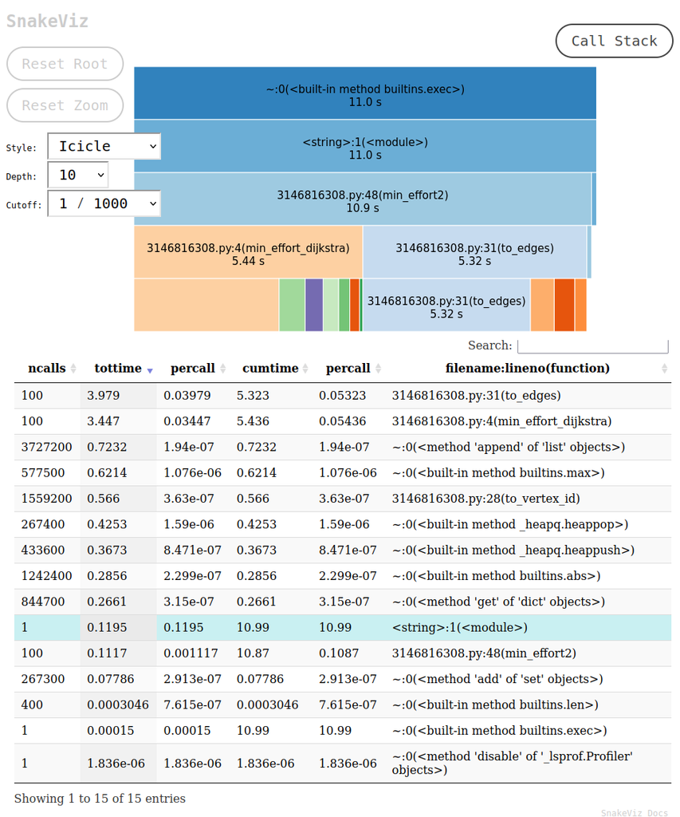

```python
%%snakeviz

for i in range(0,100):
    min_effort2(heights)
```

## Python foreign call C++

If we need further optimization, it will be probably on the high performance platform (C/C++) side.

So why not try with python's ctypes foreign language interface?

We find a piece of [dijkstra written in C++](https://www.geeksforgeeks.org/dijkstras-shortest-path-algorithm-using-priority_queue-stl/) using std::priority_queue, that we can retrofit into the minimum efforts problem. (again please excuse the cryptic variable names)

The code has been changed a bit to eliminate pointers (the original code does not delete their newed objects, and ctypes will leak memory because python's garbage collector don't collect foreign objects), add early exit shortcut if destination vertex is found, and added grid to adjacency list conversion logic.

**mineffort.h**:

```
#include<bits/stdc++.h>
using namespace std;
const int INF=INT_MAX;

typedef pair<int, int> iPair;

// This class represents a directed graph using adjacency list representation
class Graph
{
    vector< vector<iPair > > adj;
public:
    explicit Graph(int num_vertexes); // Constructor
    Graph(int nrow, int ncol, const int *heights); //Constructor from grid
    void addEdge(int u, int v, int w); // function to add an edge to graph
    vector<int> minimumEffort(int s, int t=-1);
};

// python's ctypes expect C ABI
extern "C"{
    int min_effort_c(int n_row, int n_col, const int *heights);
};
```

**mineffort.cpp**:

```
#include "mineffort.h"

int to_vertex_id(int r,int c, int n_col)
{
    return c+r*n_col;
}

Graph::Graph(int num_vertexes):adj(num_vertexes){}

Graph::Graph(int nrow, int ncol, const int *heights):adj(nrow*ncol) {

    for(auto r=0; r < nrow; r++){
        for(auto c=0; c < ncol; c++){
            auto v= to_vertex_id(r,c,ncol);
            for(auto dr:{-1,1}){
                for(auto dc:{-1,1}){
                    auto nr=r+dr, nc=c+dc;
                    if (nr>=0 and nr<nrow and nc>=0 and nc<ncol){
                        auto nv = to_vertex_id(nr,nc,ncol);
                        auto effort = abs(heights[v]-heights[nv]);
                        addEdge(v,nv,effort);
                    }
                }
            }
        }
    }
}

void Graph::addEdge(int u, int v, int w)
{
    adj[u].push_back(make_pair(v, w));
}

vector<int> Graph::minimumEffort(int src, int tgt)
{
    // Create a priority queue to store vertices that
    // are being preprocessed. This is weird syntax in C++.
    // Refer below link for details of this syntax
    // https://www.geeksforgeeks.org/implement-min-heap-using-stl/
    priority_queue< iPair, vector <iPair> , greater< > > pq;

    // Create a vector for distances and initialize all
    // distances as infinite (INF)
    vector<int> dist(adj.size(), INF);

    // Insert source itself in priority queue and initialize
    // its distance as 0.
    pq.push(make_pair(0, src));  //(distance, vertex)
    dist[src] = 0;

    /* Looping till priority queue becomes empty (or all
    distances are not finalized) */
    while (!pq.empty())
    {
        // The first vertex in pair is the minimum distance
        // vertex, extract it from priority queue.
        // vertex label is stored in second of pair (it
        // has to be done this way to keep the vertices
        // sorted distance (distance must be first item
        // in pair)
        int u = pq.top().second;
        pq.pop();

        if (u==tgt) break;

        // 'it' is used to get all adjacent vertices of a vertex
        for (auto it = adj[u].begin(); it != adj[u].end(); ++it)
        {
            // Get vertex label and weight of current adjacent
            // of u.
            int v = (*it).first;
            int weight = (*it).second;

            auto new_dist_v_u = max(dist[u], weight);

            if (dist[v] > new_dist_v_u)
            {
                // Updating effort of v
                dist[v] = new_dist_v_u;
                pq.push(make_pair(new_dist_v_u, v));
            }
        }
    }
    return dist;
}

extern "C"
{
    int min_effort_c(int n_row, int n_col, const int *heights)
    {
        auto from = 0, to = n_row*n_col-1;

        Graph g(n_row,n_col,heights);
        auto dist = g.minimumEffort(from,to);
        return dist[to];
    }
};
```

build shared library by using the cmake statement, for ctypes to import:

```
add_library(min_effort SHARED mineffort.cpp)
```

```python
from ctypes import *
libmin_effort = cdll.LoadLibrary("./libmin_effort.so")
heightf = list(itertools.chain(*heights))
HeightsArrayType = c_int*len(heightf)
heights_array = HeightsArrayType(*heightf)
```

Suppose this function passes unit tests, we now measure the performance:

```python
timeit("libmin_effort.min_effort_c(len(heights),len(heights[0]),heights_array)", globals=globals(),number=100)/100
```

```
0.001835466189950239
```